# Practical Machine Learning

Mtoti

April 03 2016

## **Problem Description**

### Informal Description

Using devices such as Jawbone Up, Nike FuelBand, and Fitbit it is now possible to collect a large amount of data about personal activity relatively inexpensively. These type of devices are part of the quantified self movement - a group of enthusiasts who take measurements about themselves regularly to improve their health, to find patterns in their behavior, or because they are tech geeks. One thing that people regularly do is quantify how much of a particular activity they do, but they rarely quantify how well they do it.

### Formal Description

The goal of your project is to predict the manner in which they did the exercise. This is the “classe” variable in the training set. Use data from accelerometers on the belt, forearm, arm, and dumbell of 6 participants. They were asked to perform barbell lifts correctly and incorrectly in 5 different ways. More information is available from the website here: http://groupware.les.inf.puc-rio.br/har (see the section on the Weight Lifting Exercise Dataset).

You may use any of the other variables to predict with. You should create a report describing how you built your model, how you used cross validation, what you think the expected out of sample error is, and why you made the choices you did. You will also use your prediction model to predict 20 different test cases.

### Provided Data

The training data for this project are available here: https://d396qusza40orc.cloudfront.net/predmachlearn/pml-training.csv

The test data are available here: https://d396qusza40orc.cloudfront.net/predmachlearn/pml-testing.csv

The data for this project come from this source: http://groupware.les.inf.puc-rio.br/har. If you use the document you create for this class for any purpose please cite them as they have been very generous in allowing their data to be used for this kind of assignment.

## **Exploratory Data Analysis and Data Preparation**

### Loading required libraries

```r
# Required libraries
suppressMessages(library(caret));suppressMessages(library(rattle));library(ROCR)
suppressMessages(library(ggplot2));suppressMessages(library(rpart.plot));
suppressMessages(library(randomForest));suppressMessages(library(gridExtra));
suppressMessages(library(gbm));suppressMessages(library(splines));
suppressMessages(library(plyr));suppressMessages(library(formattable));
suppressMessages(library(parallel));suppressMessages(library(doParallel))
```

### Loading, Preprocessing and Feature Selection

```r
if (!file.exists("pml-training.csv")) {
    # Download the file if it is not represented in the working directory
  fileUrl <- "https://d396qusza40orc.cloudfront.net/predmachlearn/pml-training.csv"
  download.file(fileUrl, destfile = "pml-training.csv")
}

if (!file.exists("pml-testing.csv")) {
    # Download the file if it is not represented in the working directory
  fileUrl <- "https://d396qusza40orc.cloudfront.net/predmachlearn/pml-testing.csv"
  download.file(fileUrl,destfile = "pml-testing.csv")
}

TrainingData <- read.csv("pml-training.csv")
TestingData <- read.csv("pml-testing.csv")

#Table Plot Function
plotTable <- function(pdf, choice){
if(choice=="Best.Model"){
formattable(pdf, list(
  Algorithm = formatter("span",
    style = x ~ vmap(x, A = style(color = "green", font.weight = "bold"), NA)),
  Accuracy = formatter("span",
    style = x ~ style(color = ifelse(rank(-x) <= 1, "green", "gray"),font.weight = "bold")),
  OOB.error.rate = formatter("span",
    style = x ~ style(color = ifelse(rank(-x) <= 1, "green", "gray"),font.weight = "bold")),
  Best.Model = formatter("span",
    style = x ~ style(color = ifelse(rank(-x) <= 1, "green", "red"),font.weight = "bold"),
    x ~ icontext(ifelse(rank(-x) <= 1, "ok", "remove"), ifelse(rank(-x) <= 1, "Yes", "No")))

),  align = c("l","l","l","l","c"))

  } else{
formattable(pdf, list(
  Algorithm = formatter("span",
    style = x ~ vmap(x, A = style(color = "green", font.weight = "bold"), NA)),
  Accuracy = formatter("span",
    style = x ~ style(color = ifelse(rank(-x) <= 1, "green", "gray"),font.weight = "bold")),
  OOB.error.rate = formatter("span",
    style = x ~ style(color = ifelse(rank(-x) <= 1, "green", "gray"),font.weight = "bold")),
  Final.Model = formatter("span",
    style = x ~ style(color = ifelse(rank(-x) <= 1, "green", "red"),font.weight = "bold"),
    x ~ icontext(ifelse(rank(-x) <= 1, "ok", "remove"), ifelse(rank(-x) <= 1, "Yes", "No")))

),  align = c("l","l","l","l","c"))
 }
}
```

#### Are there missing or corrupted values? If any remove them.

```r
isMissing <- sapply(TrainingData, function (x) any(is.na(x) | x == ""))
# remove missing values
notMissing <- isMissing[isMissing==FALSE] # logical
notMissingChr <- c(names(notMissing)) # character vector
notMissingData <- TrainingData[, notMissingChr] # subset that have all values
```

There are 100 columns with missing values, and 60 columns that do not have any missing values in `training dataset`.

#### What data types are the attributes?

```r
str(notMissingData[, 1:10])
```

```
## 'data.frame':    19622 obs. of  10 variables:
##  $ X                   : int  1 2 3 4 5 6 7 8 9 10 ...
##  $ user_name           : Factor w/ 6 levels "adelmo","carlitos",..: 2 2 2 2 2 2 2 2 2 2 ...
##  $ raw_timestamp_part_1: int  1323084231 1323084231 1323084231 1323084232 1323084232 1323084232 1323084232 1323084232 1323084232 1323084232 ...
##  $ raw_timestamp_part_2: int  788290 808298 820366 120339 196328 304277 368296 440390 484323 484434 ...
##  $ cvtd_timestamp      : Factor w/ 20 levels "02/12/2011 13:32",..: 9 9 9 9 9 9 9 9 9 9 ...
##  $ new_window          : Factor w/ 2 levels "no","yes": 1 1 1 1 1 1 1 1 1 1 ...
##  $ num_window          : int  11 11 11 12 12 12 12 12 12 12 ...
##  $ roll_belt           : num  1.41 1.41 1.42 1.48 1.48 1.45 1.42 1.42 1.43 1.45 ...
##  $ pitch_belt          : num  8.07 8.07 8.07 8.05 8.07 8.06 8.09 8.13 8.16 8.17 ...
##  $ yaw_belt            : num  -94.4 -94.4 -94.4 -94.4 -94.4 -94.4 -94.4 -94.4 -94.4 -94.4 ...
```

From the structure of the data, we can see that the first 7 variables `X`, `user_name`, `raw_timestamp_part_1`, `raw_timestamp_part_2`, `cvtd_timestamp`, `new_window`, `num_window` are simply administrative parameters that will not help us predict the activity the subjects are performing. As a result, we are going to remove those 7 variables out.

#### Candidate Predictor Variables

Subset the primary training dataset to include only the **predictor candidates**.

```r
# change found values to FALSE cause they not predictors
isPredictor <- !grepl("^X|name|timestamp|window", names(notMissing))
predCandidates <- names(notMissing)[isPredictor] # subset predictor names
```

There are 52 predictor candidates varibles at this point in time.

#### Identifying Correlated Candidate Predictors

Since the goal in selecting models is to avoid overfitting on training data and minimize error on test data. When more predictors used, the model is more likely to overfit the training data. So will remove highly correlated predictor from our **`predictor candidates`**.

```r
predCandData <- TrainingData[, predCandidates]
# calculate correlation matrix
correlationMatrix <- cor(predCandData[,1:length(predCandData)-1])
# find attributes that are highly corrected (ideally >0.75)
highlyCorrelated <- findCorrelation(correlationMatrix, cutoff=0.90)
#sort
highlyCorrelated <- sort(highlyCorrelated)
```

There are 7 highly correlated variables out of 52 predictor candidates varibles at this point in time.

#### Final Candidate Predictors

```r
reducedPred <- c(names(predCandData[,-c(highlyCorrelated)]))
```

After removing highly correlated variable we have 45 final candidate predictor variables.

## **Evaluate Algorithms**

### Splice Training Data

We partition the cleaned training data in order to create a training set and a test set. Considering the variable “classe” as an outcome, We assume that the training set and the test set respectively correspond to 70% and 30% of the total training data.

```r
seed <- as.numeric(as.Date("2016-04-08"))
set.seed(seed)
predCandData <- TrainingData[, reducedPred] #Entire cleaned dataset
inTrain <- createDataPartition(y=predCandData$classe,p=0.7,list=FALSE)
training <- predCandData[inTrain,] # random subsample
crossvalid <- predCandData[-inTrain,] #random OOB subsample
```

### Check for near zero variance.

```r
nzv <- nearZeroVar(training, saveMetrics=TRUE)
if (any(nzv$nzv)) nzv else msg<-"no variables with near zero variance"
```

There are no variables with near zero variance in the training dataset.

### Train the Candidate Models

Next we fit three prediction models using the training set, apply different models on the test set and compare these models in terms of Accuracy and out of Sample error. The models that we choose are `Decision Tree`, `Random Forest`, and `Boosting`.

Start out by setting up the parallel clusters

```r
cl <- makeCluster(detectCores() - 1)
registerDoParallel(cl)
```

```r
# Decision Tree
DTreemodelsys<-system.time(DTreemodel <- train(classe~.,data=training,preProc=c('center', 'scale'), method="rpart"))
# Random Forest
RFmodelsys<-system.time(RFmodel <- randomForest(classe~., data=training,preProc=c('center', 'scale'), importance=TRUE))
# Boosting
# run the generalized boosted regression model
BfitControl <- trainControl(method="repeatedcv", number=3, repeats=3)
# run the generalized boosted regression model with trees
Boostmodelsys<-system.time(Boostmodel <- train(classe~.,data=training,preProc=c('center', 'scale'),method="gbm",trControl =BfitControl, verbose=FALSE))
```

### Test the Candidate Models

Now that we’ve trained the models, we can use it to score the `test set` and see how well your model predicts on unseen data.

```r
# Decision Tree model predict on testing data set
DTreepredict <- predict(DTreemodel,newdata=crossvalid)
# Random Forest model predict on testing data set
RFpredict <- predict(RFmodel,newdata=crossvalid)
# Boosting model predict on testing data set
Boostpredict <- predict(Boostmodel,newdata=crossvalid)
```

Stop the clusters

```r
stopCluster(cl)
gc()
```

### Evaluate candidate Models

```r
#show predicted result for all three models
DTreecm <- confusionMatrix(crossvalid$classe,DTreepredict)
DTreeAccuracy <- round(DTreecm$overall[1],4)
DTreeOOB <- round(sum(DTreemodel$err.rate)*2,0)
RFcm <- confusionMatrix(crossvalid$classe,RFpredict)
RFAccuracy <- round(RFcm$overall[1],4)
RFOOB <- sprintf("%.4f",(sum(RFmodel$err.rate)*2)/10000)
Boostcm <- confusionMatrix(crossvalid$classe,Boostpredict)
BoostAccuracy <- round(Boostcm$overall[1],4)
BoostOOB <- round(sum(Boostmodel$err.rate)*2,0)

df <- data.frame(
      Algorithm = c("Decision Tree", "Random Forest","Boosting"),
      Time.to.Train = c(as.numeric(DTreemodelsys)[3],as.numeric(RFmodelsys)[3],as.numeric(Boostmodelsys)[3]),
      Accuracy = percent(c(DTreeAccuracy,RFAccuracy,BoostAccuracy),digits=1L),
      OOB.error.rate = percent(c("",RFOOB,""),digits=2L),
      Best.Model = percent(c(DTreeAccuracy,RFAccuracy,BoostAccuracy),digits=1L))
```

`True Positive(TP)` and `False Positive(FP)`; `True Negative(TN)` and `False Negative(FN)`

Sensitivity`[TP/(TP+FN)]` - Ratio of items predicted as Positives which are actually positive versus total number of Positive items.

Specificity`[TN/(TN+FP)]` - Ratio of items predicted as Negative which are actually negative versus total number of Negative items.

Increase in Sensitivity leads to increase in TPs and decrease in FNs. Similarly increase in Specificity means increase in TNs and decrease in FPs.

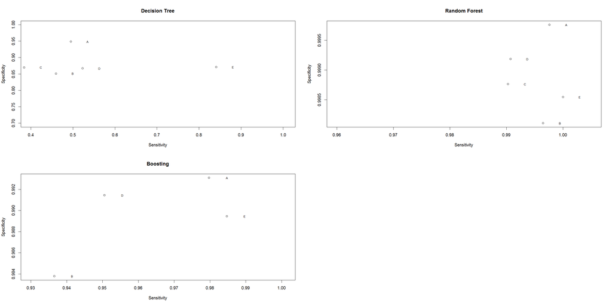

```r
# compare the sensitivity and specificity btw random forest and boosting method
par(mfrow=c(2,2))
plot(DTreecm$byClass, main="Decision Tree", xlim=c(0.4, 1.005), ylim=c(0.7,1))
text(DTreecm$byClass[,1]+0.04, DTreecm$byClass[,2], labels=LETTERS[1:5], cex= 0.7)
plot(RFcm$byClass, main="Random Forest", xlim=c(0.96, 1.005))
text(RFcm$byClass[,1]+0.003, RFcm$byClass[,2], labels=LETTERS[1:5], cex= 0.7)
plot(Boostcm$byClass, main="Boosting", xlim=c(0.93, 1.001))
text(Boostcm$byClass[,1]+0.005, Boostcm$byClass[,2], labels=LETTERS[1:5], cex= 0.7)
```

The figures show random forest is better in both aspects. Therefore, we select random forest as our final prediction model.

| Algorithm | Time.to.Train | Accuracy | OOB.error.rate | Best.Model |
| --- | --- | --- | --- | --- |
| Decision Tree | 34.07 | 49.9% |  | No |
| Random Forest | 92.01 | 99.5% | 0.58% | Yes |
| Boosting | 287.03 | 95.7% |  | No |

As we can see **`randomForest`** is the better performing algorithm with **`0.58%`** out-of-bag (OOB) error rate. When the model is applied to the validation set for cross validation, the model achieved an accuracy of **`99.5%`**, which indicates the actual error rate is **`0.5%`**.

As a result we select the random forest-based model apply it to 20 use cases in the testing data in order to predict how well 20 exercises are being performed (classe variable).

### Evaluate Final Model

```r
threshold <- quantile(RFmodel$importance[,1], 0.3)
filters <- RFmodel$importance[,1] >= threshold
FinalRFmodelPred<-names(filters[filters==TRUE])
FinalRFmodelPred <- c(FinalRFmodelPred, "classe")
seed <- as.numeric(as.Date("2016-04-08"))
set.seed(seed)
FinalpredData <- TrainingData[, FinalRFmodelPred]
inTrain <- createDataPartition(y=FinalpredData$classe,p=0.7,list=FALSE)
Finaltraining <- FinalpredData[inTrain,]
Finalcrossvalid <- FinalpredData[-inTrain,]
# Random Forest
FinalRFmodelsys<-system.time(FinalRFmodel <- randomForest(classe~.,data=Finaltraining,preProc=c('center', 'scale'),importance=T))
# Random Forest model predict on testing data set
FinalRFpredict <- predict(FinalRFmodel,newdata=Finalcrossvalid)
FinalRFcm <- confusionMatrix(Finalcrossvalid$classe,FinalRFpredict)
FinalRFAccuracy <- round(FinalRFcm$overall[1],4)
FinalRFOOB <- sprintf("%.4f",(sum(FinalRFmodel$err.rate)*2)/10000)

RFdf <- data.frame(
                  Algorithm = "Random Forest",
                  Time.to.Train = as.numeric(FinalRFmodelsys)[3],
                  Accuracy = percent(as.numeric(FinalRFAccuracy),digits=1L),
                  OOB.error.rate = percent(as.numeric(FinalRFOOB),digits=2L),
                  Final.Model = percent(as.numeric(FinalRFAccuracy),digits=1L))

#writers_df<-dataframe(Algorithm,Time.to.Train,Accuracy, OOB.error.rate )
plotTable(RFdf, "Final.Model")
```

| Algorithm | Time.to.Train | Accuracy | OOB.error.rate | Final.Model |
| --- | --- | --- | --- | --- |
| Random Forest | 58.35 | 99.5% | 0.58% | Yes |

#### Final Predictors

As you can see, we manage to reduce the number of predictors from 45 to 31 final predictors with affecting the accuracy or OOB-rate.

## **Prediction**

We apply the final random forest model to the testing data in order to predict the “classe” outcome of each of the 20 considered use cases.

```r
# apply random forest model to use cases
results <- predict(FinalRFmodel,TestingData)
```